# NNS vs. XGBOOST

# Intro

## `NNS.boost`

`NNS.boost` is a routine in the `NNS` R-package for ensemble classification based on the `NNS.reg` routine. You can read more about the underlying clustering and regression methods here:

`Nonparametric Regression Using Clusters` http://rdcu.be/tz0J.

## `xgboost`

Abstract:

`xgboost` is a highly effective and widely used machine learning method. In this paper, we describe a scalable end-to-end tree boosting system called XGBoost, which is used widely by data scientists to achieve state-of-the-art results on many machine learning challenges. We propose a novel sparsity-aware algorithm for sparse data and weighted quantile sketch for approximate tree learning. More importantly, we provide insights on cache access patterns, data compression and sharding to build a scalable tree boosting system. By combining these insights, XGBoost scales beyond billions of examples using far fewer resources than existing systems.

Full paper available here: https://arxiv.org/abs/1603.02754

### Install the Latest Version of `NNS (>= 0.4.4)` and `xgboost`

```r
library(devtools); install_github('OVVO-Financial/NNS', ref = "NNS-Beta-Version")
require(NNS)
require(plyr)
require(xgboost)
require(methods)
require(pROC)
```

# Example #1: UCI Credit Approval Classification

Basic example and other methods provided here https://rpubs.com/omicsdata/credit.

## Step 1: Load Data UCI Credit Screening

```r
dataset = read.table("http://archive.ics.uci.edu/ml/machine-learning-databases/credit-screening/crx.data",sep=",", header=F, na.strings="?")
dataset = dataset[complete.cases(dataset),]
head(dataset)
```

|  | V1 | V2 | V3 | V4 | V5 | V6 | V7 | V8 | V9 | V10 | V11 | V12 | V13 | V14 | V15 | V16 |
| --- | --- | --- | --- | --- | --- | --- | --- | --- | --- | --- | --- | --- | --- | --- | --- | --- |
| 1 | b | 30.83 | 0.000 | u | g | w | v | 1.25 | t | t | 1 | f | g | 202 | 0 | + |
| 2 | a | 58.67 | 4.460 | u | g | q | h | 3.04 | t | t | 6 | f | g | 43 | 560 | + |
| 3 | a | 24.50 | 0.500 | u | g | q | h | 1.50 | t | f | 0 | f | g | 280 | 824 | + |
| 4 | b | 27.83 | 1.540 | u | g | w | v | 3.75 | t | t | 5 | t | g | 100 | 3 | + |
| 5 | b | 20.17 | 5.625 | u | g | w | v | 1.71 | t | f | 0 | f | s | 120 | 0 | + |
| 6 | b | 32.08 | 4.000 | u | g | m | v | 2.50 | t | f | 0 | t | g | 360 | 0 | + |

## Step 2: Run `NNS.boost` and `xgboost` over 1,000 iterations

```r
accuracy = list()

## convert factor into dummy variable matrix
into_factor = function(x){
     if(class(x) == "factor"){
         n = length(x)
         data.fac = data.frame(x=x, y=1:n)
         output = model.matrix(y~x, data.fac)[,-1]

     }
     else{
        output = x
     }
     output
}

### Prepare dataset for xgboost
dataset2 = dataset

dataset2 = colwise(into_factor)(dataset2)
dataset2 = do.call(cbind, dataset2)
dataset2 = as.data.frame(dataset2)


## For parallel processing
cores = detectCores()
cl <- makeCluster(cores[1]-1)
registerDoParallel(cl)


accuracy <- foreach(i = 1:1000,.packages = c("NNS","pROC","xgboost","plyr"))%dopar%{
set.seed(123+i)
n = dim(dataset)[1]
index = sample(n, round(0.7*n))

### NNS.dataset
train = dataset[index,]
test=dataset[-index,]

nns.predictions = NNS.boost(IVs.train = train[,1:15],
                          DV.train = train[,16],
                          IVs.test= test[,1:15], feature.importance = FALSE,
                          representative.sample = FALSE,
                          epochs = 100, learner.trials = 100,
                          depth = "max", ncores = 1, subcores = 1)$results

accuracy$nns = auc(roc(as.numeric(test[,16]),round(nns.predictions)))


### xgboost dataset
train.xg = dataset2[index,]
test.xg = dataset2[-index,]
label = as.matrix(train.xg[,38, drop=F])
data = as.matrix(train.xg[,-38, drop=F])
data2 = as.matrix(test.xg[,-38, drop=F])
label2 = as.matrix(test.xg[,38,drop=F])

### Prepare xgboost parameters
xgmat = xgb.DMatrix(data, label=label, missing = -10000)
param = list("object" = "binary:logistic", "best:eta" = 1, "bst:max_depth"=10, "eval_metric" = "logloss", "silent"=1,"nthread"=16,"min_child_weight"=1.45)
nround = 500

### Run xgboost model
bst = xgb.train(param, xgmat, nround)
res1 = predict(bst, data2)

pre1 = ifelse(res1>0.5, 1, 0)

accuracy$xgb = auc(roc(as.numeric(label2), pre1))

return(accuracy)
}

stopCluster(cl)
registerDoSEQ()
```

## Step 3: Compare Accuracy

On average `NNS` performs just as well or better than `xgboost` on varous seeds. Instead of using just the standard deviation of results, we are comparing the lower partial moment `LPM()`, because (like finance) really good estimates to the upside should not be penalized as merely an increase in variance!

```r
nns.accuracy=unlist(lapply(accuracy, `[[`, 1))
xgb.accuracy=unlist(lapply(accuracy, `[[`, 2))

rbind(
  "Mean NNS" = mean(nns.accuracy),
  "Mean XGB" = mean(xgb.accuracy),
  "LPM NNS" = LPM(2, mean(nns.accuracy), nns.accuracy),
  "LPM XGB" = LPM(2, mean(xgb.accuracy), xgb.accuracy))
```

```
##                  [,1]
## Mean NNS 0.8608110673
## Mean XGB 0.8558886609
## LPM NNS  0.0002272005
## LPM XGB  0.0002693473
```

```r
t.test(nns.accuracy,xgb.accuracy)
```

```
##
##  Welch Two Sample t-test
##
## data:  nns.accuracy and xgb.accuracy
## t = 4.9593, df = 1991.5, p-value = 7.674e-07
## alternative hypothesis: true difference in means is not equal to 0
## 95 percent confidence interval:
##  0.002975846 0.006868967
## sample estimates:
## mean of x mean of y
## 0.8608111 0.8558887
```

# Example #2: `agaricus` Dataset

This time we will utilize the data from within `xgboost`, the `agaricus` dataset. Mushrooms described in terms of physical characteristics; classification: poisonous or edible.

```r
### Load [agaricus] dataset
data(agaricus.train, package = 'xgboost')
data(agaricus.test, package = 'xgboost')

### Set up data for xgboost
dtrain = xgb.DMatrix(agaricus.train$data, label = agaricus.train$label)
dtest = xgb.DMatrix(agaricus.test$data, label = agaricus.test$label)


### Create parameters and run xgboost
watchlist = list(train = dtrain, eval = dtest)

param = list(max_depth = 2, eta = 1, silent = 1, nthread = 2,
              objective = "binary:logistic", eval_metric = "auc")

bst = xgb.train(param, dtrain, nrounds = 2, watchlist)
### Set up data for NNS
agaricus.iv.train = as.matrix(agaricus.train$data)
agaricus.dv.train = agaricus.train$label
agaricus.iv.test = as.matrix(agaricus.test$data)
agaricus.dv.test = agaricus.test$label


### Run NNS.boost
a = NNS.boost(IVs.train = agaricus.iv.train, DV.train = agaricus.dv.train,
            IVs.test = agaricus.iv.test, feature.importance = FALSE,
            representative.sample = TRUE, epochs = 100, learner.trials = 100,
            depth = "max", ncores = 1, subcores = 1)$results


### Evaluate accuracy
mean(round(a) == as.numeric(agaricus.dv.test))
```

```
## [1] 1
```

```r
### Evaluate AUC
auc(roc(as.numeric(agaricus.dv.test), round(a)))
```

```
## Area under the curve: 1
```

# Comments

`NNS` is a full machine learning methodology, all based on the seamless underlying clustering `NNS.part` embedded within the regression method `NNS.reg`.

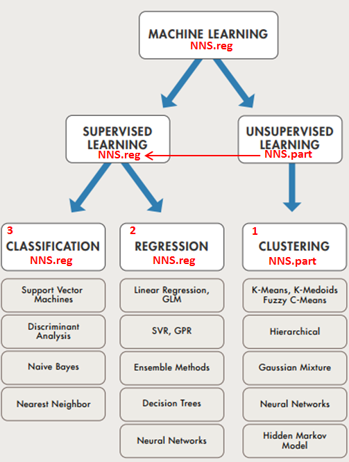

`xgboost` is maintained by an army of computer scientists, `NNS` is maintained by a single economist! Speed overwhelmingly favors `xgboost`, but with ample resources and collaboration, `NNS` will be able to compete on that front as well. Additional computational efficiency would permit even more `NNS` testing and further improvement!

`NNS` is not a one-trick pony, as it has been demonstrated to excel in time-series forecasting, nonlinear continuous regressions, and provide solutions for econometric applications. See the following examples:

- `NNS` Forecasting Presentation Download the .pdf file here: https://ssrn.com/abstract=3382300
- `NNS` Forecasting vs. KERAS LSTM Deep Learning View and download the .html file here: https://htmlpreview.github.io/?https://github.com/OVVO-Financial/NNS/blob/NNS-Beta-Version/examples/Sunspots_example.html
- `Classification Using NNS Clustering Analysis` https://ssrn.com/abstract=2864711
- `The 7 Reasons Most Econometric Investments Fail - NNS Contributions Towards Solutions` View and download the .html file here: https://htmlpreview.github.io/?https://github.com/OVVO-Financial/NNS/blob/NNS-Beta-Version/examples/7_Econometic_Reasons.html

I look forward to further discussions and collaboration with those equally as passionate about these issues, and open to embracing alternative solutions. If you found this presentation interesting or useful, please feel free to reach out via e-mail: ovvo.financial.systems@gmail.com

Thanks for your interest!